# Tephritid species identification using CNN

Aaron Harmer

2023-04-12

## Summary

A convolution neural network was trained via transfer learning to identify Tephritidae genera using wing images. After initial poor results classifying images at the species level (66% accuracy), the model was retrained to classify images at the genus level. Threefold cross-validation was used to achieve an accuracy of 99% (667/674) at predicting class. The image set comprised 674 images in 8 classes. The image set was sorted into three folds using stratified round-robin cross-validation. Each set had a 2/3 training, 1/3 test split. Classes were defined by genus name.

### Image pre-processing

Images were prepared by:

- Converting colour images to grayscale
- Blurring to reduce image grain noise
- Standardising brightness and contrast to mean = 0.5, contrast range = ±2 standard deviations, with the extreme values clipped
- Squashing and downsampling to 299 by 299 pixels to match the network input filter size

### Model training

Transfer learning was used to retrain an Xception model initially trained on the Imagenet dataset. The model was retrained three times, each run was initially set for 200 epochs but with an early-stopping callback and learning rate of 1e-04. Each model was fine-tuned at a learning rate of 1e-05, again with early-stopping set.

Images were augmented to prevent over-fitting and increase the robustness of the model to variation in additional images added later. Image augmentations included:

- Random horizontal and vertical shift up to 10%
- Random zoom up to ±10%
- Random rotation up to ±25 degrees

## Results

The model achieved an average accuracy of 99% (667 correct/7 wrong) across the three runs. Each model stopped before reaching 200 epochs with accuracy and loss both plateauing (Figure 1).

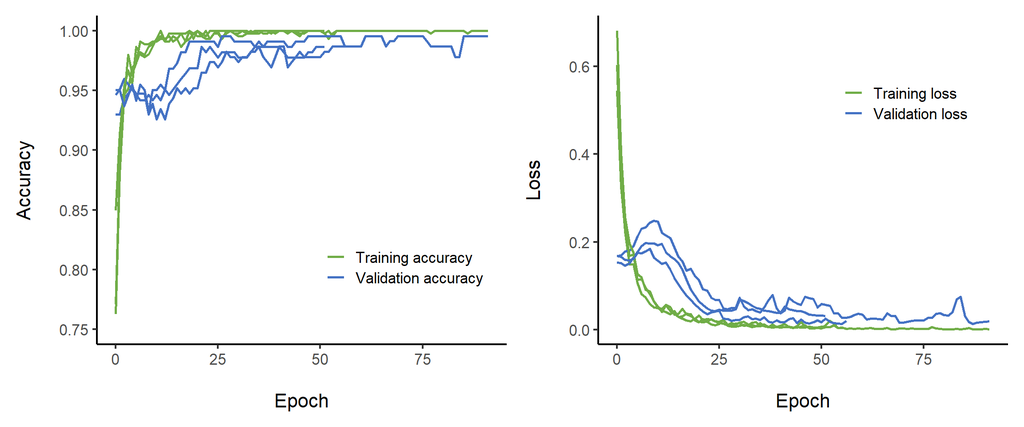

### Classification report for each class

| class | precision | recall | f1-score | support |
| --- | --- | --- | --- | --- |
| austrotephritis | 1.00 | 1.00 | 1.00 | 12 |
| bactrocera | 0.96 | 1.00 | 0.98 | 22 |
| ceratitis | 1.00 | 1.00 | 1.00 | 5 |
| dacus | 1.00 | 0.90 | 0.95 | 10 |
| procecidochares | 1.00 | 1.00 | 1.00 | 7 |
| sphenella | 1.00 | 1.00 | 1.00 | 4 |
| trupanea | 1.00 | 1.00 | 1.00 | 159 |
| urophora | 1.00 | 1.00 | 1.00 | 10 |
| accuracy | NA | NA | 0.99 | 229 |
| macro avg | 0.99 | 0.99 | 0.99 | 229 |
| weighted avg | 1.00 | 1.00 | 1.00 | 229 |

### Incorrect identifications during validation

The 7 images in the table below were incorrectly identified during validation.

file

actual

predicted

score

test_img

prediction_exemplar_img

NZAC04254430_Dacus_dorsalis_wing.png

dacus

bactrocera

0.9458045

NZAC04254420_Bactrocera_curcubitae_wing.png

bactrocera

dacus

0.8321145

NZAC04254506_Bactrocera_psidii_wing.png

bactrocera

dacus

0.6960590

NZAC04254482_Dacus_melanotus_wing.png

dacus

bactrocera

0.8597282

NZAC04254435_Dacus_dorsalis_wing.png

dacus

bactrocera

0.7137015

NZAC04254483_Dacus_melanotus_wing.png

dacus

bactrocera

0.8096635

NZAC04254411.png

trupanea

austrotephritis

0.5962892

### Representative activation maps for each class

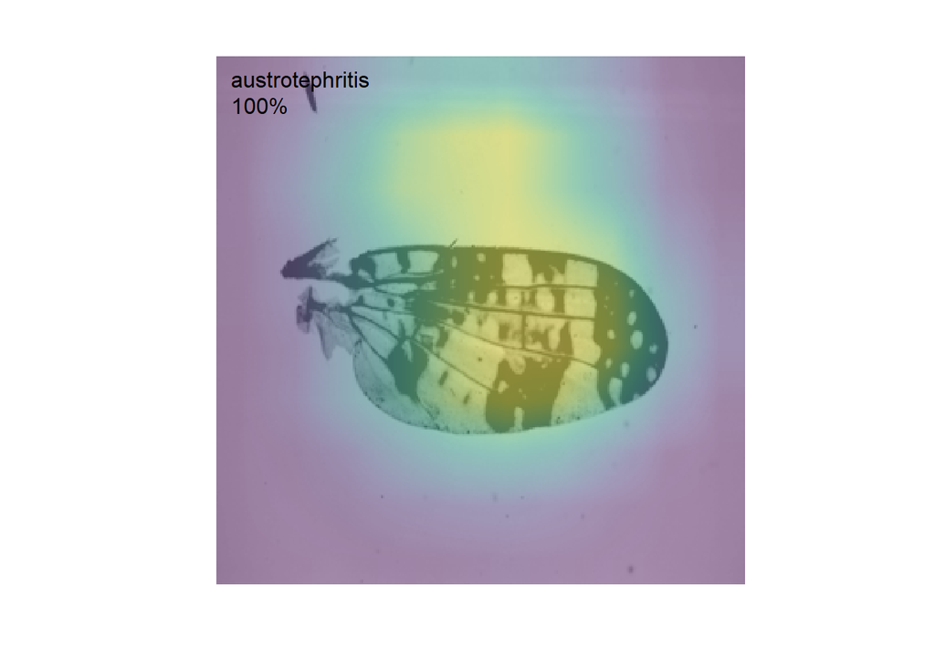

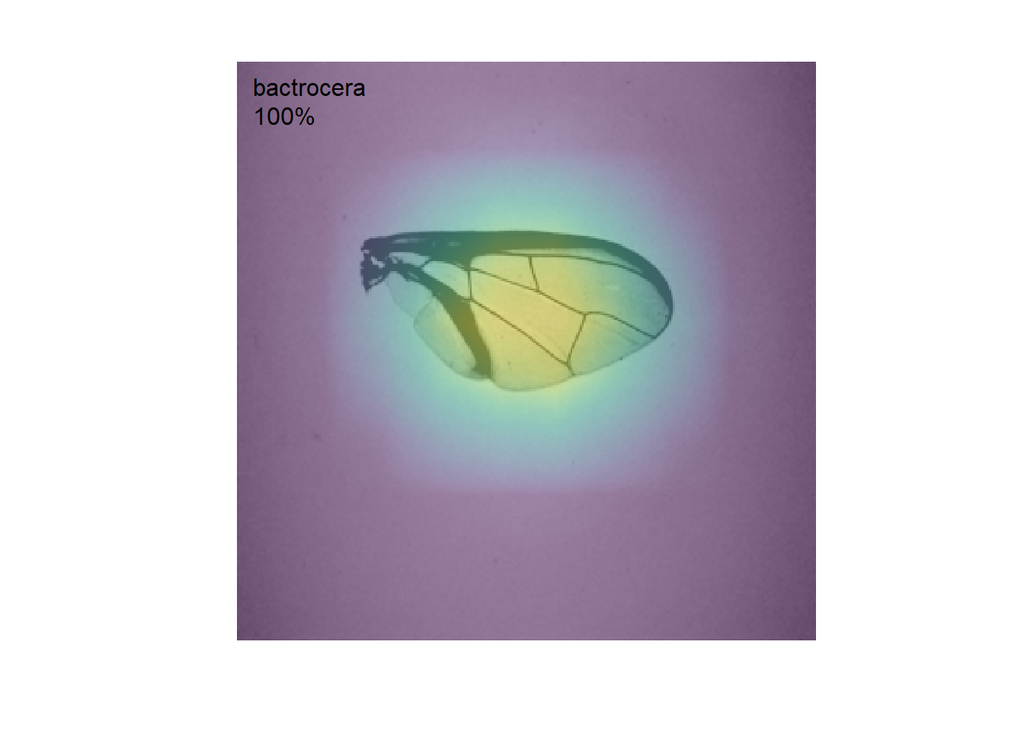

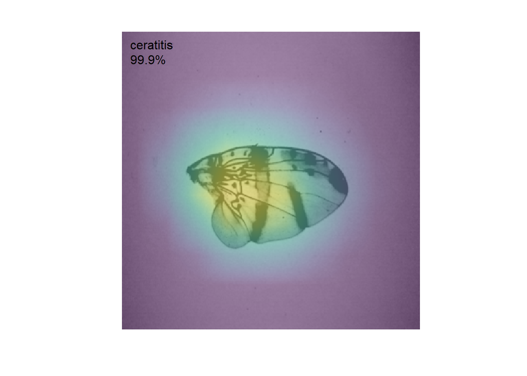

[figure not shown]

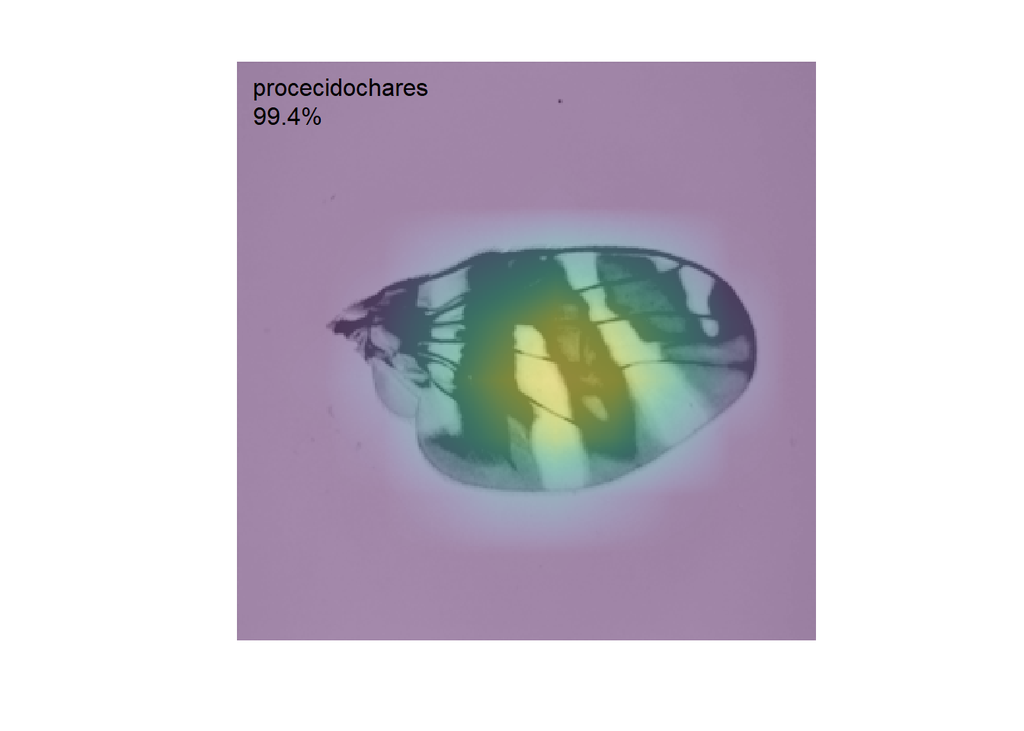

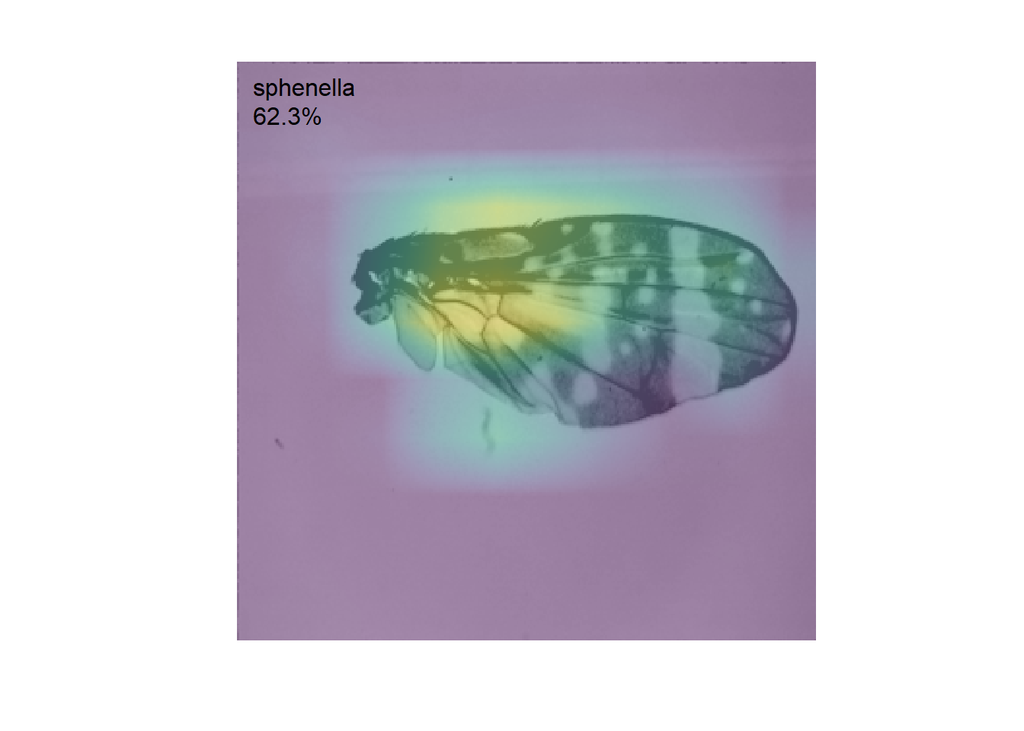

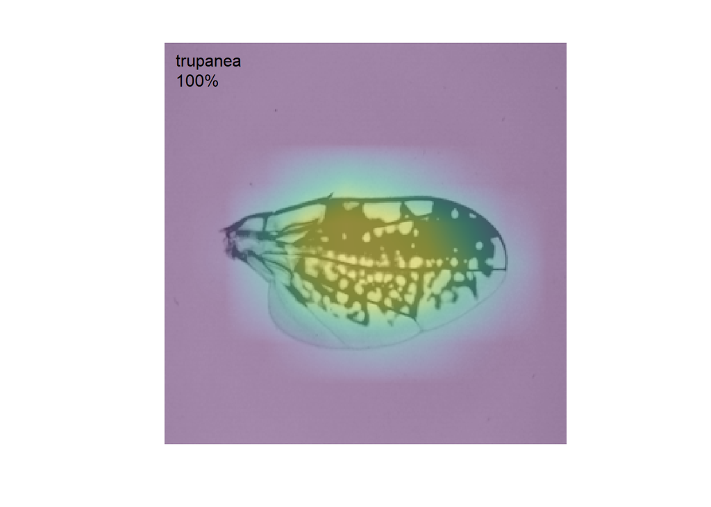

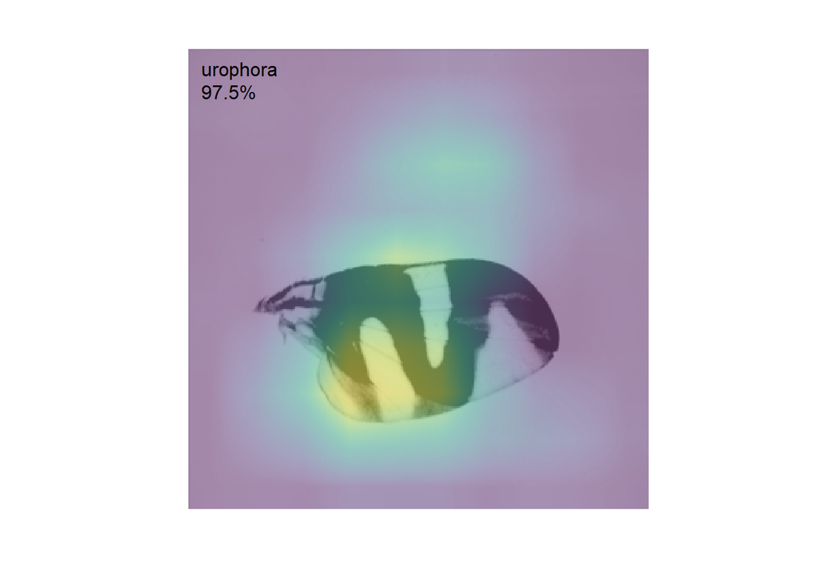